# 425 HW3

Eda Kocakarin & Yusuf Ulucoban - IE425 - Spring 2022

2022-05-14

## 1

It is available as a pdf in the submission.

## 2

### Consider the data set “Default” in the package “ISLR”, where “default” is the output attribute. Partition the data set into training and test sets with 75% going into the training set by using a seed value of 425. Using k-NN classification with different values of k between 1 and 10, determine the error rate, sensitivity, and specificity for the instances in the test set.

First of all, categorical variable is eliminited and numerical input variables are scaled. Then for train&test sets, 0.75 ratio is used. Train &test and output’s train&test datasets are formed. For k=1 to k=10, different KNN values are used to predict “default” output. Concerning different kNN values, error rate, sensitivity and specificity are calculated. Above you can see the result table.

```r
## knn classification
library(class)
library(ISLR)
def=Default
set.seed(425)
def2=def[,-2]
def3=scale(def2[,-1])
train=sample(1:10000,7500)

train.def=def3[train,]
test.def=def3[-train,]
train.def.output=def2$default[train]
test.def.output=def2$default[-train]
```

```r
knn.pred.def = NULL
error.rate.def = NULL
sensitivity.def= NULL
specificity.def= NULL

for(i in 1:10){
set.seed(425)
knn.pred.def=knn(train.def,test.def,train.def.output,k=i)
error.rate.def[i] = mean(test.def.output != knn.pred.def)
table=table(test.def.output,knn.pred.def)
sensitivity.def[i]=sensitivity(table)
specificity.def[i]=specificity(table)
}
results=data.table(error.rate.def, sensitivity.def, specificity.def)
results
```

```
##     error.rate.def sensitivity.def specificity.def
##  1:         0.0420       0.9805624       0.2926829
##  2:         0.0412       0.9801817       0.2948718
##  3:         0.0336       0.9815195       0.4000000
##  4:         0.0320       0.9811553       0.4237288
##  5:         0.0264       0.9824418       0.5490196
##  6:         0.0240       0.9824847       0.6222222
##  7:         0.0252       0.9824633       0.5833333
##  8:         0.0240       0.9820920       0.6279070
##  9:         0.0236       0.9828851       0.6304348
## 10:         0.0236       0.9820993       0.6428571
```

Minimum of these value are selected and these minimum values kNN number determined.

```r
min.error.rate = min(error.rate.def)
Kdef.error = which(error.rate.def == min.error.rate)
#KNN=9&10 has the smallest error rate which:
min.error.rate
```

```
## [1] 0.0236
```

```r
max.sensitivity = max(sensitivity.def)
Kdef.sensitivity = which(sensitivity.def == max.sensitivity)
#KNN=9 has the highest sensitivity rate which:
max.sensitivity
```

```
## [1] 0.9828851
```

```r
min.specificity=min(specificity.def)
Kdef.specificity = which(specificity.def == min.specificity)
#KNN=1 has the smallest specificity rate which:
min.specificity
```

```
## [1] 0.2926829
```

## 3

### A) Partition the data set into training and test sets with 80% going into the training set by using a seed value of 425. Whenever you need to use set.seed function, use set.seed(425).

```r
#train and test sets are splitted using split from CaTools
set.seed(425)
split=sample.split(hr$left,SplitRatio=0.8)
hr_train=subset(hr,split==TRUE)
hr_test=subset(hr,split==FALSE)
```

### B) Fit a logistics regression model using the observations in the training dataset. Comment on which input attributes are important in making predictions.

To examine the importance input variables, lets add all input variables into the logistic regression model and make comments.

```
##
## Call:
## glm(formula = left ~ satisfaction_level + last_evaluation + number_project +
##     average_montly_hours + time_spend_company + Work_accident +
##     promotion_last_5years + sales + salary, family = "binomial",
##     data = hr_train)
##
## Deviance Residuals:
##     Min       1Q   Median       3Q      Max
## -2.2507  -0.6665  -0.4012  -0.1127   3.0752
##
## Coefficients:
##                         Estimate Std. Error z value Pr(>|z|)
## (Intercept)           -1.6425796  0.2180854  -7.532 5.00e-14 ***
## satisfaction_level    -4.1187663  0.1095643 -37.592  < 2e-16 ***
## last_evaluation        0.8068798  0.1676005   4.814 1.48e-06 ***
## number_project        -0.3034575  0.0237267 -12.790  < 2e-16 ***
## average_montly_hours   0.0042927  0.0005751   7.464 8.40e-14 ***
## time_spend_company     0.2823291  0.0176007  16.041  < 2e-16 ***
## Work_accident         -1.4915177  0.1000863 -14.902  < 2e-16 ***
## promotion_last_5years -1.5256723  0.2969206  -5.138 2.77e-07 ***
## saleshr                0.0519894  0.1487667   0.349   0.7267
## salesIT               -0.1758603  0.1355307  -1.298   0.1944
## salesmanagement       -0.4460185  0.1778454  -2.508   0.0121 *
## salesmarketing        -0.0499081  0.1483331  -0.336   0.7365
## salesproduct_mng      -0.2071890  0.1446530  -1.432   0.1521
## salesRandD            -0.6967443  0.1637001  -4.256 2.08e-05 ***
## salessales            -0.0923078  0.1142274  -0.808   0.4190
## salessupport          -0.0033851  0.1222047  -0.028   0.9779
## salestechnical        -0.0340815  0.1191251  -0.286   0.7748
## salarylow              2.0497732  0.1470553  13.939  < 2e-16 ***
## salarymedium           1.5035363  0.1477939  10.173  < 2e-16 ***
## ---
## Signif. codes:  0 '***' 0.001 '**' 0.01 '*' 0.05 '.' 0.1 ' ' 1
##
## (Dispersion parameter for binomial family taken to be 1)
##
##     Null deviance: 13172  on 11998  degrees of freedom
## Residual deviance: 10269  on 11980  degrees of freedom
## AIC: 10307
##
## Number of Fisher Scoring iterations: 5
```

Stars represent importance of input attributes. As you can see below, some features are *very important with 3 star* in making predictions.

-satisfaction_level

-last_evaluation

-number_project

-average_montly_hours

-time_spend_company

-Work_accident

-promotion_last_5years

-salesRandD

-salarylow

-salarymediuM

Besides, salesmanagement* has very *low importance* on model prediction. Lastly, some input attributes are *not important* to construct a model.

-saleshr

-salesIT

-salesmarketing

-salesproduct_mng

-salessales

-salessupport

-salestechnical

Since there are different types of sales input attribute that are not significant for this model, lets eliminate “sales” input attribute and construct new model.

```
##
## Call:
## glm(formula = left ~ satisfaction_level + last_evaluation + number_project +
##     average_montly_hours + time_spend_company + Work_accident +
##     promotion_last_5years + salary, family = "binomial", data = hr_train)
##
## Deviance Residuals:
##     Min       1Q   Median       3Q      Max
## -2.2340  -0.6669  -0.4057  -0.1172   3.1005
##
## Coefficients:
##                         Estimate Std. Error z value Pr(>|z|)
## (Intercept)           -1.7802026  0.1941471  -9.169  < 2e-16 ***
## satisfaction_level    -4.1144228  0.1092339 -37.666  < 2e-16 ***
## last_evaluation        0.7992014  0.1670374   4.785 1.71e-06 ***
## number_project        -0.3036785  0.0236564 -12.837  < 2e-16 ***
## average_montly_hours   0.0042977  0.0005734   7.495 6.62e-14 ***
## time_spend_company     0.2781983  0.0174144  15.975  < 2e-16 ***
## Work_accident         -1.5023649  0.0999428 -15.032  < 2e-16 ***
## promotion_last_5years -1.5734350  0.2953872  -5.327 1.00e-07 ***
## salarylow              2.1059271  0.1458883  14.435  < 2e-16 ***
## salarymedium           1.5529841  0.1467526  10.582  < 2e-16 ***
## ---
## Signif. codes:  0 '***' 0.001 '**' 0.01 '*' 0.05 '.' 0.1 ' ' 1
##
## (Dispersion parameter for binomial family taken to be 1)
##
##     Null deviance: 13172  on 11998  degrees of freedom
## Residual deviance: 10308  on 11989  degrees of freedom
## AIC: 10328
##
## Number of Fisher Scoring iterations: 5
```

When we look at the AIC value we can say that even there is non-significant attributes, first model is better. Therefore, continuing with the first model is meaningful.

### C) Provide the Confusion Matrix along with sensitivity, specificity, precision and recall on the test set obtained by the logistic regression model.

```
##     Min.  1st Qu.   Median     Mean  3rd Qu.     Max.
## 0.001213 0.069916 0.162832 0.234805 0.348777 0.920558
```

```
##         0         1
## 0.1799842 0.4103234
```

We need to determine thresholds for cutoff values.

```r
## Confusion matrix  different threshold=cutoff values
#threshold>=0.4
table(hr_test$left,prediction_hrleft>=0.4)
```

```
##
##     FALSE TRUE
##   0  2024  262
##   1   349  365
```

```r
#threshold>=0.35
table(hr_test$left,prediction_hrleft>=0.35)
```

```
##
##     FALSE TRUE
##   0  1965  321
##   1   290  424
```

```r
#threshold>=0.3
table(hr_test$left,prediction_hrleft>=0.3)
```

```
##
##     FALSE TRUE
##   0  1866  420
##   1   225  489
```

```r
#threshold>=0.2
table(hr_test$left,prediction_hrleft>=0.2)
```

```
##
##     FALSE TRUE
##   0  1595  691
##   1   134  580
```

```
## Confusion Matrix and Statistics
##
##           Reference
## Prediction    0    1
##          0 2024  349
##          1  262  365
##
##                Accuracy : 0.7963
##                  95% CI : (0.7815, 0.8106)
##     No Information Rate : 0.762
##     P-Value [Acc > NIR] : 3.938e-06
##
##                   Kappa : 0.4139
##
##  Mcnemar's Test P-Value : 0.0005029
##
##             Sensitivity : 0.5112
##             Specificity : 0.8854
##          Pos Pred Value : 0.5821
##          Neg Pred Value : 0.8529
##              Prevalence : 0.2380
##          Detection Rate : 0.1217
##    Detection Prevalence : 0.2090
##       Balanced Accuracy : 0.6983
##
##        'Positive' Class : 1
##
```

### D) Draw the ROC curve using the ROCR package and provide the auc value.

Below you can see ROC curve.

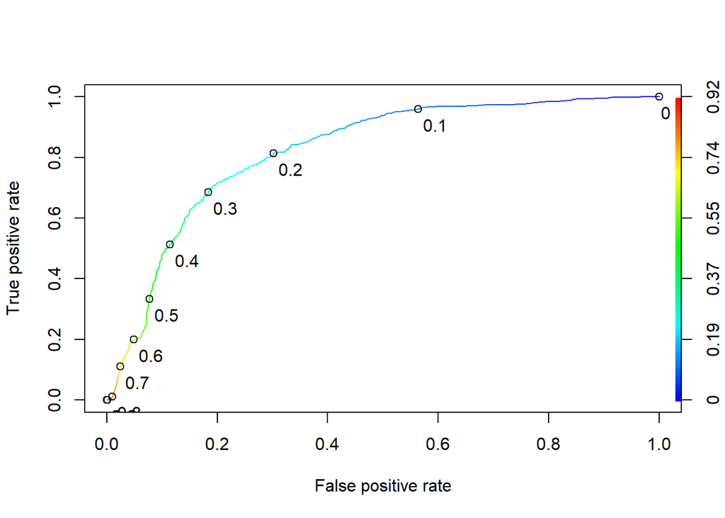

```
## [1] 0.8221515
```

Model’s AUC can be seen above which is sufficient enough.